# LPS Switch

Published

September 9, 2025

# Experiment summary

Female microglia switch (MC+) and cre-negative (+/+) littermates were given tamoxifen to induce allelic switching at 11 months. 10 days later they were given intraperitoneal injections with LPS to cause inflammation. Brains were collected 24 hours after LPS injections.

|  | mouseID | genotype |
| --- | --- | --- |
| M10 | STMEM_101 | MC/+ |
| M11 | STMEM_106 | MC/+ |
| M12 | STMEM_108 | MC/+ |
| M13 | STMEM9_150 | MC/+ |
| M3 | STMEM_171 | MC/+ |
| M5 | STMEM_150 | MC/+ |
| M6 | STMEM_132 | MC/+ |
| M7 | STMEM_117 | MC/+ |
| M8 | STMEM_93 | MC/+ |
| M9 | STMEM_100 | MC/+ |
| NS10 | STMEM_121 | +/+ |
| NS12 | STMEM9_151 | +/+ |
| NS2 | STMEM_172 | +/+ |
| NS3 | STMEM_168 | +/+ |
| NS4 | STMEM_147 | +/+ |
| NS5 | STMEM_148 | +/+ |
| NS6 | STMEM_133 | +/+ |
| NS7 | STMEM_102 | +/+ |
| NS9 | STMEM_118 | +/+ |

# Bioinformatic methods

## RNAseq Data Processing and Analysis

Data processing was performed using the `nf-core/rnaseq` workflow (v3.19.0). The pipeline was executed with `Nextflow` v24.10.4 on the Morgan Computer Core high-performance computing cluster at the University of Kentucky. All analyses were containerized using Singularity.

**Quality Control and Preprocessing**: Raw sequencing reads underwent comprehensive quality assessment using `FastQC` to evaluate per-base sequence quality, GC content, sequence length distribution, and potential adapter contamination. Low-quality bases and adapter sequences were removed using `Trim Galore!`, which combines `Cutadapt` and `FastQC` functionalities to ensure optimal read quality for downstream analysis.

**Reference Genome and Annotation**: Trimmed reads were aligned to the mouse reference genome (Mus musculus GRCm39 primary assembly) obtained from Ensembl, using the corresponding GTF annotation file (Ensembl release 114) to define gene boundaries and features.

**Read Alignment and Quantification**: `STAR` was used to perform splice-aware alignment of reads to the reference genome, generating coordinate-sorted BAM files. Simultaneously, `Salmon` quantified transcript abundance as raw counts and normalized as Transcripts Per Million (TPM) values.

## Differential Expression Analysis (MC/+ *vs.* +/+)

Differential expression between experimental conditions was assessed using Wald tests implemented in `DESeq2` (version 1.46.0) using the scaled gene count matrix generated by the `nf-core` pipeline. P-values were adjusted for multiple testing using the Benjamini-Hochberg false discovery rate (FDR) correction. Differentially expressed genes (DEGs) were identified using an adjusted p-value (FDR) < 0.05.

# Results

Two filtering steps were applied to the raw gene counts:

1. genes with low expression were removed by retaining only those with a raw count of at least 10 in 5 or more samples.
2. Following this, a second filter was applied to ensure robust expression, keeping only genes with a median expression count greater than 10 across all retained samples.

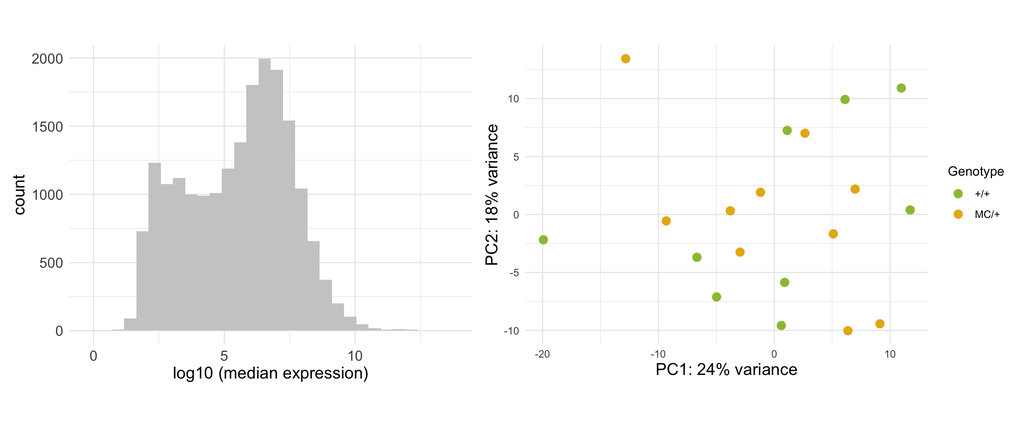

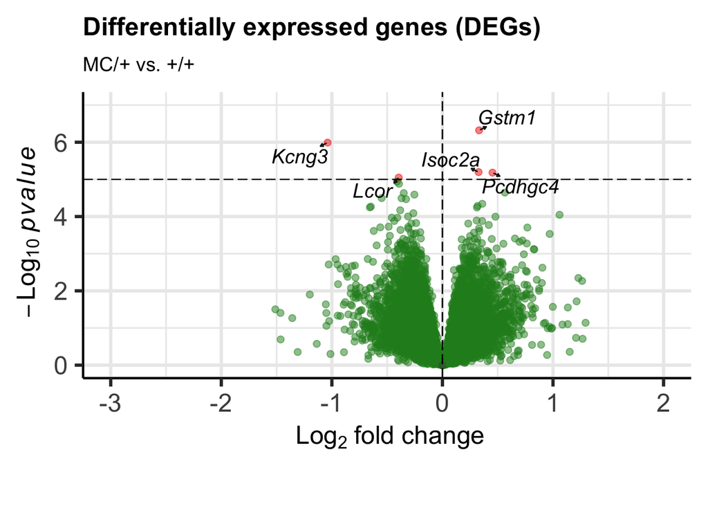